# Panel Data

Michael Winton

7/25/2018

## Introduction

Panel data is also referred to as longitudinal data. It has both cross-section and time series elements (although typically a limited number of time series observations). It involves repeat sampling of the same individuals, companies, cities, etc… repeatedly. It enables us to understand behavioraly dynamics as well as their relation to other variables.

Within-individual change is characterized by some relevant summary of changes in the repeated measurements on each individual. We expect correlation between multiple observations for a particular individual over time. We also expect heterogenous variability - change in the variance of the responses over the duration of the study. **These features violate the fundamental independence assumption in many traditional statistical techniques (including OLS regression).** We cannot treat $n$ “once-repeated” observations the same as $2n$ independent observations. (We could confirm this with a Durbin-Watson test if we wanted.)

Statistical models for longitudinal data have two main features:

1. a model for the covariance among repeated measures
2. a model for the mean response, and its dependence on covariates

## EDA on a 2-Period Panel

First, find out how many panels there are. Then explore patterns of features in each panel. We also need to look at “dynamic temporal dependence” of features.

```r
data(crime2)
# str(crime2)
head(crime2)
```

|  | pop | crimes | unem | officers | pcinc | west | nrtheast | south | year | area | d87 | popden | crmrte | offarea | lawexpc | polpc | lpop | loffic | lpcinc | llawexpc | lpopden | lcrimes | larea | lcrmrte | clcrimes | clpop | clcrmrte | lpolpc | clpolpc | … |
| --- | --- | --- | --- | --- | --- | --- | --- | --- | --- | --- | --- | --- | --- | --- | --- | --- | --- | --- | --- | --- | --- | --- | --- | --- | --- | --- | --- | --- | --- | --- |
| 1 | 229528 | 17136 | 8.2 | 326 | 8532 | 1 | 0 | 0 | 82 | 44.6 | 0 | 5146 | 74.66 | 7.309 | 850.9 | 1.420 | 12.34 | 5.787 | 9.052 | 6.746 | 8.546 | 9.749 | 3.798 | 4.313 | NA | NA | NA | 0.3509 | NA | … |
| 2 | 246815 | 17306 | 3.7 | 321 | 12155 | 1 | 0 | 0 | 87 | 44.6 | 1 | 5534 | 70.12 | 7.197 | 2262.4 | 1.301 | 12.42 | 5.771 | 9.405 | 7.724 | 8.619 | 9.759 | 3.798 | 4.250 | 0.0098715 | 0.07261 | -0.06274 | 0.2628 | -0.088070 | … |
| 3 | 814054 | 75654 | 8.1 | 1621 | 7551 | 1 | 0 | 0 | 82 | 375.0 | 0 | 2171 | 92.93 | 4.323 | 875.1 | 1.991 | 13.61 | 7.391 | 8.929 | 6.774 | 7.683 | 11.234 | 5.927 | 4.532 | NA | NA | NA | 0.6888 | NA | … |
| 4 | 933177 | 83960 | 5.4 | 1803 | 11363 | 1 | 0 | 0 | 87 | 375.0 | 1 | 2488 | 89.97 | 4.808 | 1069.6 | 1.932 | 13.75 | 7.497 | 9.338 | 6.975 | 7.819 | 11.338 | 5.927 | 4.500 | 0.1041698 | 0.13657 | -0.03240 | 0.6586 | -0.030160 | … |
| 5 | 374974 | 31352 | 9.0 | 633 | 8343 | 1 | 0 | 0 | 82 | 49.8 | 0 | 7530 | 83.61 | 12.711 | 1121.9 | 1.688 | 12.83 | 6.450 | 9.029 | 7.023 | 8.927 | 10.353 | 3.908 | 4.426 | NA | NA | NA | 0.5236 | NA | … |
| 6 | 406297 | 31364 | 5.9 | 685 | 11729 | 1 | 0 | 0 | 87 | 49.8 | 1 | 8159 | 77.19 | 13.755 | 1545.6 | 1.686 | 12.91 | 6.529 | 9.370 | 7.343 | 9.007 | 10.353 | 3.908 | 4.346 | 0.0003834 | 0.08023 | -0.07984 | 0.5223 | -0.001279 | … |

```r
# find number of panels (in this case, 46)
table(crime2$year)
```

```
##
## 82 87
## 46 46
```

Recognize that distributions may change over time, and also that the relationship between outcome variable and predictors may change over time. `unem` in the following plot is an example of both.

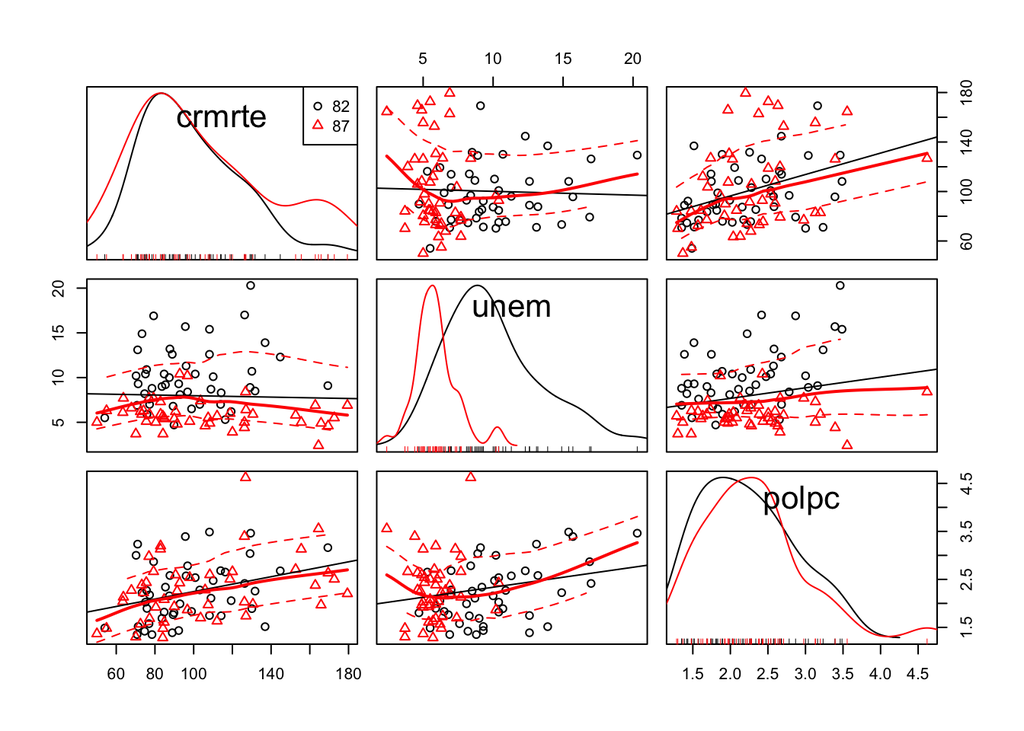

```r
# note the syntax for plotting plotting by year
scatterplotMatrix(~crmrte + unem + polpc | year, data=crime2)
```

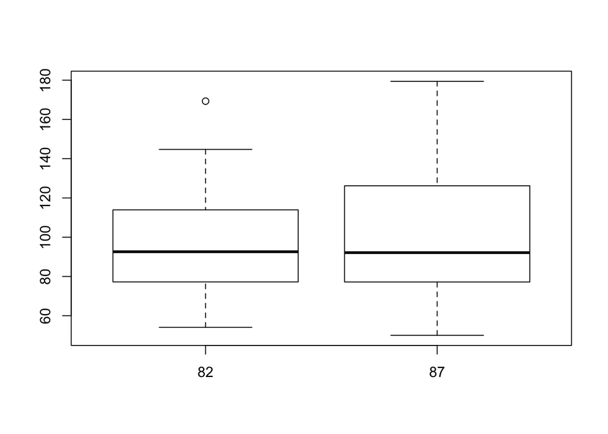

```r
# boxplots for each panel (ggplot2 w/ jitter looks better)
boxplot(crmrte ~ year, data=crime2)
```

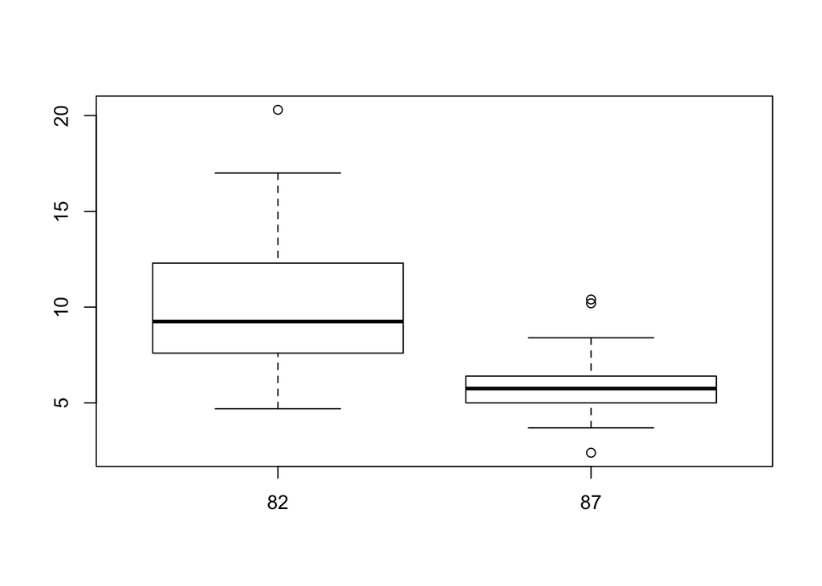

```r
boxplot(unem ~ year, data=crime2)
```

```r
# look at summary stats for each panel (outcome)
summary(crime2$crmrte[crime2$year==82])
```

```
##    Min. 1st Qu.  Median    Mean 3rd Qu.    Max.
##    54.1    77.5    92.6    97.7   113.0   169.3
```

```r
summary(crime2$crmrte[crime2$year==87])
```

```
##    Min. 1st Qu.  Median    Mean 3rd Qu.    Max.
##    50.0    77.7    92.1   103.9   126.2   179.4
```

```r
# look at summary stats for each panel (predictors)
summary(crime2$unem[crime2$year==82])
```

```
##    Min. 1st Qu.  Median    Mean 3rd Qu.    Max.
##    4.70    7.72    9.25   10.05   12.05   20.30
```

```r
summary(crime2$unem[crime2$year==87])
```

```
##    Min. 1st Qu.  Median    Mean 3rd Qu.    Max.
##    2.40    5.00    5.75    5.89    6.38   10.40
```

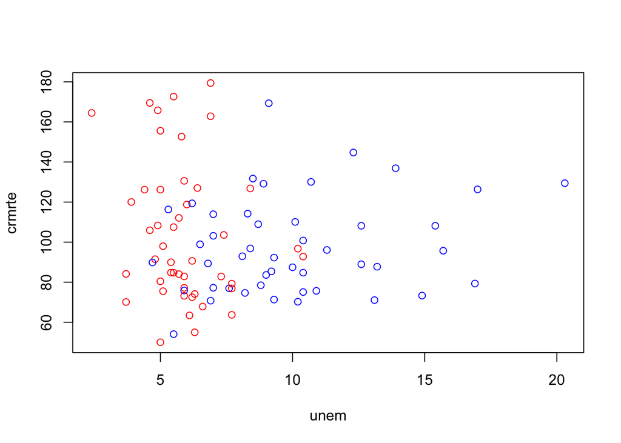

```r
# scatterplot shows that relationship changes with time
with(crime2,
     plot(unem, crmrte, col=c('blue','red')[as.factor(year)])
)
```

If we were to naively do a separate OLS regression for each year, they likely would suffer from omitted variable biases.

## Unobserved Effect Models (aka. Fixed Effect Models)

Using a panel dataset, we can effectively deal with unobserved variables and also capture a dynamic that would not have been possible with cross-section data. There are two types of unobserved variables:

1. Time invariant
2. Time-varying

Let’s look at the mathematical model for a 2-period unobserved effect (fixed effect) model:

$$y_{it} = \delta_1 + \delta_2 d2_t + \beta_1 x_{it} + a_i + \epsilon_{it}$$
where $t=1,2$. $d2_t$ is a dummy variable for $t=2$. $\epsilon_{it}$ is the idiosyncratic error, which is time-varying. $a_i$ represents *all* unboserved, time invariant variables that effect $y_{it}$. (Other names for this include unobserved effect, fixed effect, and unobserved heterogeneity.)

## Pooled OLS (applied to an Unobserved Effect Model)

We’ll use the `crime` dataset as an example. We could *pool* the data for the two years and use OLS. The drawback is that pooled OLS requires that the observed explanatory variable $x_{it}$ and the unobserved effect $a_i$ are *uncorrelated* in order to produce a *consistent* estimator for $\beta_1$.

For pooled OLS, we rewrite the equation in a *composite error* form:

$$crmrte_{it} = \delta_1 + \delta_2 d87_t + \beta_1 unem_{it} + \mu_{it}$$
where in reality $\mu_{it} = a_i + \epsilon_{it}$.

Recall that OLS requires that $x_{it}$ (in this case $unem_{it}$) be uncorrelated with $\mu_{it}$. This is unlikely to hold with panel data since the same observations are observed multiple times. Even if $\epsilon_{it}$ is uncorrelated with $x_{it}$, it’s likely that the pooled OLS estimate will be biased and inconsistent if $a_i$ and $x_{it}$ are correlated. This **heterogeneity bias** is the result of omitting time-invariant, individual-specific variables from the model.

```r
# pooled OLS does a bad job with the crime2 data
summary(lm(crmrte~d87 + unem, data=crime2))
```

```
##
## Call:
## lm(formula = crmrte ~ d87 + unem, data = crime2)
##
## Residuals:
##    Min     1Q Median     3Q    Max
## -53.47 -21.79  -6.27  18.30  75.11
##
## Coefficients:
##             Estimate Std. Error t value Pr(>|t|)
## (Intercept)   93.420     12.739    7.33  9.9e-11 ***
## d87            7.940      7.975    1.00     0.32
## unem           0.427      1.188    0.36     0.72
## ---
## Signif. codes:  0 '***' 0.001 '**' 0.01 '*' 0.05 '.' 0.1 ' ' 1
##
## Residual standard error: 30 on 89 degrees of freedom
## Multiple R-squared:  0.0122, Adjusted R-squared:  -0.00999
## F-statistic: 0.55 on 2 and 89 DF,  p-value: 0.579
```

What’s wrong with this model?

- coefficients are not statistically significant
- `unem` coefficient is not practically significant either
- model explains almost none of the data (poor $R^2)
- serial correlation of repeated observations causes standard errors and test stats to be invalid

## First Difference Models

With panel data, though, we can avoid the *heterogeneity bias* issues, and the need to make an unrealistic assumption about lack of correlation between $a_i$ and $x_{it}$, that come with pooled OLS. Instead we can use first differencing. In first difference models, it is acceptable for $a_i$ and $x_{it}$ to be correlated, although $\epsilon_{it}$ and $x_{it}$ must still be uncorrelated.

In the `crmrte2` example, we want to allow unobserved variables about the cities to be correlated with the observed explanatory variables like `unem`. We use first differencing to remove these unobserved variables and estimate the variables of interest.

Take these two equations for $t=1,2$:

$$y_{i2} = \delta_1 + \delta_2 (1) + \beta_1 x_{i2} + a_i + \epsilon_{i2}$$
$$y_{i1} = \delta_1 + \delta_2 (0) + \beta_1 x_{i1} + a_i + \epsilon_{i1}$$
Subtracting from each other “differences away” the $a_i$ term:

$$y_{i2} - y_{i1} = \delta_2 + \beta_1 (x_{i2} - x_{i1}) + \epsilon_{i2} - \epsilon_{i1}$$
$$\Delta y_i = \delta_2 + \beta_1 \Delta x_i + \Delta \epsilon_i$$

This “first difference” equation is simply a cross-sectional equation in which each variable is differenced over two consecutive time periods. Using this, we can estimate the model using OLS and conduct inference, assuming the CLM assumptions are met. Specifically, this requires that $\Delta \epsilon_i$ is uncorrelated with $\Delta x_i$. This holds if $\epsilon_i$ is uncorrelated with the explanatory variable $x_i$ in *both* time periods. This is a **strict exogeneity** assumption.

In the case of the `crime2` dataset, the “change” in `crmrte` and `unem` are already given as `ccrmrte` and `cunem`, so we can just estimate the model with `lm`.

```r
summary(lm(ccrmrte ~ cunem, data=crime2))
```

```
##
## Call:
## lm(formula = ccrmrte ~ cunem, data = crime2)
##
## Residuals:
##    Min     1Q Median     3Q    Max
## -36.91 -13.37  -5.51  12.45  52.92
##
## Coefficients:
##             Estimate Std. Error t value Pr(>|t|)
## (Intercept)   15.402      4.702    3.28   0.0021 **
## cunem          2.218      0.878    2.53   0.0152 *
## ---
## Signif. codes:  0 '***' 0.001 '**' 0.01 '*' 0.05 '.' 0.1 ' ' 1
##
## Residual standard error: 20.1 on 44 degrees of freedom
##   (46 observations deleted due to missingness)
## Multiple R-squared:  0.127,  Adjusted R-squared:  0.107
## F-statistic: 6.38 on 1 and 44 DF,  p-value: 0.0152
```

**NOTE: this model will not work if an explanatory variable is constant over the time period, because it will also be differenced away.**

### Differencing with >2 time periods

If we have $N$ individuals, $k$ variables for each, and 3 time periods, then the general fixed effect model can we written as:

$$y_{it} = \delta_1 + \delta_2 d2_t + \delta_3 d3_t + \beta_1 x_{it1} + ... + \beta_k x_{itk} + a_i + \epsilon_{it} \ (\forall t=1,2,3)$$
As with the two-period case, the time-dependent error term must be uncorrelated with the explanatory variables in each time period. This means that the explanatory variables are *strictly exogenous* after the unobserved effect $a_i$ is removed through differencing. Note: this assumption is *violated* if an important, time-varying variable is omitted from the model.

For differencing in the case of $T=3$, we can subtract period 1 from period 2, and period 2 from period 3. We can estimate the model using OLS and conduct inference, assuming the CLM assumptions are met.

## Example First Differences Model: Grunfeld

We use the `plm` (Panel Linear Model) function in R.

```r
data("Grunfeld")
str(Grunfeld)
```

```
## 'data.frame':    200 obs. of  5 variables:
##  $ firm   : int  1 1 1 1 1 1 1 1 1 1 ...
##  $ year   : int  1935 1936 1937 1938 1939 1940 1941 1942 1943 1944 ...
##  $ inv    : num  318 392 411 258 331 ...
##  $ value  : num  3078 4662 5387 2792 4313 ...
##  $ capital: num  2.8 52.6 156.9 209.2 203.4 ...
```

```r
head(Grunfeld)
```

|  | firm | year | inv | value | capital |
| --- | --- | --- | --- | --- | --- |
| 1 | 1 | 1935 | 317.6 | 3078 | 2.8 |
| 2 | 1 | 1936 | 391.8 | 4662 | 52.6 |
| 3 | 1 | 1937 | 410.6 | 5387 | 156.9 |
| 4 | 1 | 1938 | 257.7 | 2792 | 209.2 |
| 5 | 1 | 1939 | 330.8 | 4313 | 203.4 |
| 6 | 1 | 1940 | 461.2 | 4644 | 207.2 |

```r
tail(Grunfeld)
```

|  | firm | year | inv | value | capital |
| --- | --- | --- | --- | --- | --- |
| 195 | 10 | 1949 | 4.21 | 71.24 | 7.39 |
| 196 | 10 | 1950 | 3.42 | 69.05 | 8.74 |
| 197 | 10 | 1951 | 4.67 | 83.04 | 9.07 |
| 198 | 10 | 1952 | 6.00 | 74.42 | 9.93 |
| 199 | 10 | 1953 | 6.53 | 63.51 | 11.68 |
| 200 | 10 | 1954 | 5.12 | 58.12 | 14.33 |

```r
# look at the panels
table(Grunfeld$firm)
```

```
##
##  1  2  3  4  5  6  7  8  9 10
## 20 20 20 20 20 20 20 20 20 20
```

```r
# look at the time index
table(Grunfeld$year)
```

```
##
## 1935 1936 1937 1938 1939 1940 1941 1942 1943 1944 1945 1946 1947 1948 1949
##   10   10   10   10   10   10   10   10   10   10   10   10   10   10   10
## 1950 1951 1952 1953 1954
##   10   10   10   10   10
```

```r
# explicitly define the data structure
Grunfeld <- plm.data(Grunfeld, index=c('firm', 'year'))
str(Grunfeld)
```

```
## Classes 'plm.dim' and 'data.frame':  200 obs. of  5 variables:
##  $ firm   : Factor w/ 10 levels "1","2","3","4",..: 1 1 1 1 1 1 1 1 1 1 ...
##  $ year   : Factor w/ 20 levels "1935","1936",..: 1 2 3 4 5 6 7 8 9 10 ...
##  $ inv    : num  318 392 411 258 331 ...
##  $ value  : num  3078 4662 5387 2792 4313 ...
##  $ capital: num  2.8 52.6 156.9 209.2 203.4 ...
```

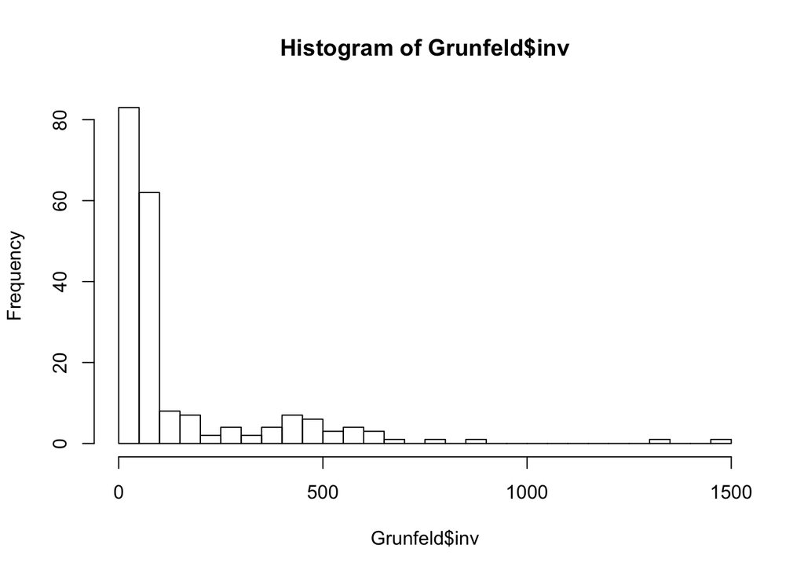

```r
# quick EDA
hist(Grunfeld$inv, breaks=50)
```

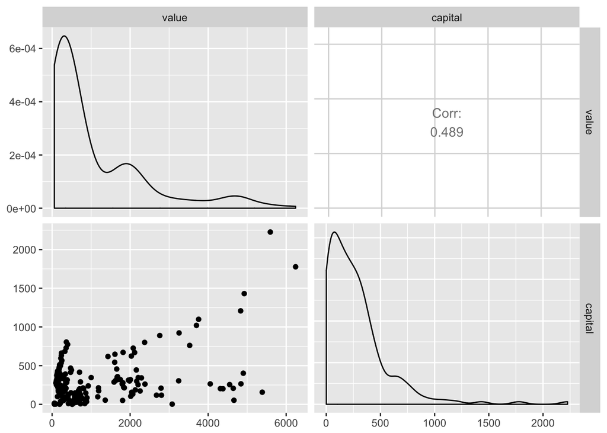

```r
# scatterplot matrix
ggpairs(Grunfeld, columns=c('value', 'capital'))
```

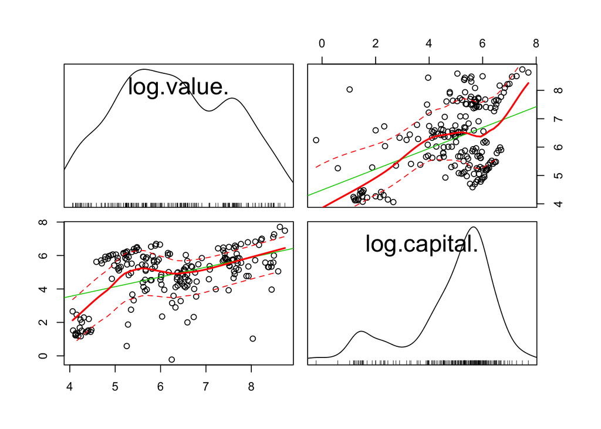

```r
# both are skewed, so try logs
scatterplotMatrix(~log(value) + log(capital), data=Grunfeld)
```

```r
# simple (naive) model as an example
grun_fd <- plm(inv ~ value + capital, data=Grunfeld, model='fd')
summary(grun_fd)
```

```
## Oneway (individual) effect First-Difference Model
##
## Call:
## plm(formula = inv ~ value + capital, data = Grunfeld, model = "fd")
##
## Balanced Panel: n = 10, T = 20, N = 200
## Observations used in estimation: 190
##
## Residuals:
##    Min. 1st Qu.  Median    Mean 3rd Qu.    Max.
##  -202.0   -15.2    -1.8    -1.4     8.0   199.3
##
## Coefficients:
##         Estimate Std. Error t-value Pr(>|t|)
## value    0.08906    0.00823   10.82  < 2e-16 ***
## capital  0.27869    0.04716    5.91  1.6e-08 ***
## ---
## Signif. codes:  0 '***' 0.001 '**' 0.01 '*' 0.05 '.' 0.1 ' ' 1
##
## Total Sum of Squares:    584000
## Residual Sum of Squares: 346000
## R-Squared:      0.409
## Adj. R-Squared: 0.406
## F-statistic: 129.597 on 1 and 188 DF, p-value: <2e-16
```

Recall that first difference model is written in terms of *changes* in each variable from one time to another. We see from the estimated regression coefficients that positive *changes* in value and capital lead to positive *change* in investment (inv).

## Example First Differences Model: Wooldridge

```r
data(crime3)
str(crime3)
```

```
## 'data.frame':    106 obs. of  12 variables:
##  $ district: int  1 1 2 2 3 3 4 4 5 5 ...
##  $ year    : int  72 78 72 78 72 78 72 78 72 78 ...
##  $ crime   : num  49.5 71.3 14.8 17.9 17.4 ...
##  $ clrprc1 : int  22 15 51 39 33 36 41 41 41 32 ...
##  $ clrprc2 : int  23 17 62 40 34 37 43 40 46 33 ...
##  $ d78     : int  0 1 0 1 0 1 0 1 0 1 ...
##  $ avgclr  : num  22.5 16 56.5 39.5 33.5 36.5 42 40.5 43.5 32.5 ...
##  $ lcrime  : num  3.9 4.27 2.69 2.88 2.85 ...
##  $ clcrime : num  NA 0.364 NA 0.189 NA ...
##  $ cavgclr : num  NA -6.5 NA -17 NA 3 NA -1.5 NA -11 ...
##  $ cclrprc1: int  NA -7 NA -12 NA 3 NA 0 NA -9 ...
##  $ cclrprc2: int  NA -6 NA -22 NA 3 NA -3 NA -13 ...
##  - attr(*, "time.stamp")= chr "25 Jun 2011 23:03"
```

```r
# we use district and year to set up the panel data
table(crime3$district)
```

```
##
##  1  2  3  4  5  6  7  8  9 10 11 12 13 14 15 16 17 18 19 20 21 22 23 24 25
##  2  2  2  2  2  2  2  2  2  2  2  2  2  2  2  2  2  2  2  2  2  2  2  2  2
## 26 27 28 29 30 31 32 33 34 35 36 37 38 39 40 41 42 43 44 45 46 47 48 49 50
##  2  2  2  2  2  2  2  2  2  2  2  2  2  2  2  2  2  2  2  2  2  2  2  2  2
## 51 52 53
##  2  2  2
```

```r
table(crime3$year)
```

```
##
## 72 78
## 53 53
```

```r
# the "c" variables are already defined as changes, so could just do lm
# but don't do it this way.  better to use plm functions
summary(lm(clcrime ~ cavgclr, data=crime3))
```

```
##
## Call:
## lm(formula = clcrime ~ cavgclr, data = crime3)
##
## Residuals:
##     Min      1Q  Median      3Q     Max
## -1.0377 -0.2196  0.0064  0.2227  0.8935
##
## Coefficients:
##             Estimate Std. Error t value Pr(>|t|)
## (Intercept)  0.09933    0.06259    1.59   0.1187
## cavgclr     -0.01665    0.00507   -3.29   0.0018 **
## ---
## Signif. codes:  0 '***' 0.001 '**' 0.01 '*' 0.05 '.' 0.1 ' ' 1
##
## Residual standard error: 0.345 on 51 degrees of freedom
##   (53 observations deleted due to missingness)
## Multiple R-squared:  0.175,  Adjusted R-squared:  0.159
## F-statistic: 10.8 on 1 and 51 DF,  p-value: 0.00184
```

```r
# build panel dataframe (either of these ways should work)
crime3_panel_df <- pdata.frame(crime3, index=c('district','year'),
                               drop.index=TRUE, row.names=TRUE)
# crime3_panel_df <- plm.data(crime3, index=c('district','year'))

# estimate model (don't use the previous "change" variables)
crime3_plm <- plm(lcrime ~ avgclr, data=crime3_panel_df, model='fd')
summary(crime3_plm)
```

```
## Oneway (individual) effect First-Difference Model
##
## Call:
## plm(formula = lcrime ~ avgclr, data = crime3_panel_df, model = "fd")
##
## Balanced Panel: n = 53, T = 2, N = 106
## Observations used in estimation: 53
##
## Residuals:
##    Min. 1st Qu.  Median    Mean 3rd Qu.    Max.
##  -1.022  -0.150   0.096   0.057   0.317   0.925
##
## Coefficients:
##        Estimate Std. Error t-value Pr(>|t|)
## avgclr -0.02190    0.00389   -5.63  7.5e-07 ***
## ---
## Signif. codes:  0 '***' 0.001 '**' 0.01 '*' 0.05 '.' 0.1 ' ' 1
##
## Total Sum of Squares:    7.36
## Residual Sum of Squares: 6.37
## R-Squared:      0.175
## Adj. R-Squared: 0.175
## F-statistic: Inf on 0 and 52 DF, p-value: NA
```

**NOTE: Jeff’s identical code in async 11.7.2 generates different results. Possibly related to `plm` version.**

## Distributed Lag Models

Panel data can also be used to estimate a *distributed lag* model in which the response variable is associated with one or more lags of a single explanatory variable. For example, we could consider a model in which this year’s crime rate is deterred by last year’s conviction rate (`clrpc`), as well as the previous year’s:

$$log(crime_{it}) = \beta_0 + \delta_0 d78_t + \beta_1 clrpc_{i,t-1} + \beta_2 clrpc_{i,t-2} + a_i + \epsilon_{it}$$

**NOTE: the async slides do not show the R code used to predict this type of model.**